# Warriors_Coach_Challenge_Analysis_2023_24

Isaac DiSanto

2024-06-16

This document contains the data analysis and visualization for my case study on NBA coach’s challenges from the 2023-24 NBA regular season. For the rest of the case study, [click here](https://www.datascienceportfol.io/isaacdisanto/projects/1).

My analysis seeks to:

- Evaluate how optimally the Warriors used their coach’s challenges compared to the rest of the NBA
- Identify trends in the data that indicate ways in which the Warriors can improve their use of coach’s challenges

All of my analysis and visualization was done with R, using the process below.

## Setup

Install and load necessary packages.

```r
if(!require(tidyverse)){
    install.packages("tidyverse")
    library(tidyverse)
}

if(!require(scales)){
    install.packages("scales")
    library(scales)
}

if(!require(knitr)){
    install.packages("knitr")
    library(knitr)
}

if(!require(kableExtra)){
    install.packages("kableExtra")
    library(kableExtra)
}
```

Import the data.

```r
csv_url <- "https://docs.google.com/spreadsheets/d/e/2PACX-1vTETjRSPA9C7arNEzafCLL1he9nInzdnBG2ZGjkq9B-BZZUhQIlKmd0RjlEJc1NseB3UywvJX2klHnt/pub?output=csv"

challenges_2023_24 <- read.csv(csv_url)
```

Convert the “Date” column of the data from the character data type to the date data type.

```r
challenges_2023_24$Date <- mdy(challenges_2023_24$Date)
```

The dataset we imported includes NBA coach’s challenge data from the 2023-24 NBA preseason, regular season, and postseason. Since we are only interested in regular season data, we’ll use a filter to create a dataframe for exclusively regular season data (regular season went from Oct 23rd to Apr 14th). We’ll utilize the kable package to view a preview of our dataset.

```r
## Create regular season dataset
reg_season <- filter(challenges_2023_24, Date >= ymd("2023-10-23"), Date <= ymd("2024-04-14"))

## Create version for displaying just first five rows
reg_season_head <- head(reg_season, 5)

## Display first five rows as a table
kable(reg_season_head, format = "html", table.attr = "class='table table-striped table-bordered'")
```

| Date | Away.Team | Home.Team | Trigger | Initial.Call | Final.Ruling | Ruling.Description | Team.Challenged | Challenge.Outcome | Period | Game.Clock…Review.is.Triggered | Video.Link |
| --- | --- | --- | --- | --- | --- | --- | --- | --- | --- | --- | --- |
| 2023-10-24 | PHX | GSW | Challenge of Called Foul | Offensive Foul | Stands | Offensive Foul | GSW | Unsuccessful | 4 | 04:41.0 | https://dmmx2.nba.com/videourlredirect?&project=/ON-AIR/0022300062_20231025_002628 |
| 2023-10-25 | ATL | CHA | Challenge of Called Foul | Offensive Foul | Overturned | Inadvertent Whistle - Away Team Retains Possession | ATL | Successful | 2 | 11:12.0 | https://dmmx2.nba.com/videourlredirect?&project=/ON-AIR/0022300063_20231025_194133 |
| 2023-10-25 | BOS | NYK | Challenge OOB | Home Team Ball | Stands | Home Team Ball | BOS | Unsuccessful | 1 | 02:30.0 | https://dmmx2.nba.com/videourlredirect?&project=/ON-AIR/0022300065_20231025_204252 |
| 2023-10-25 | OKC | CHI | Challenge of Called Foul | Defensive Foul | Overturned | Offensive Foul | OKC | Successful | 2 | 11:47.0 | https://dmmx2.nba.com/videourlredirect?&project=/ON-AIR/0022300070_20231025_204358 |
| 2023-10-25 | ATL | CHA | Challenge OOB | Away Team Ball | Overturned | Home Team Ball | CHA | Successful | 3 | 03:24.0 | https://dmmx2.nba.com/videourlredirect?&project=/ON-AIR/0022300063_20231025_204529 |

## Analysis

Now that the data is ready, it’s time to start using it to identify trends. Since the goal is to evaluate the Golden State Warriors’ use of coach’s challenges, let’s start by finding each NBA team’s challenge success rate and seeing how the Warriors (GSW) stack up to the rest of the league. We’ll do this by grouping the data by challenging team (“Team.Challenged” column) and creating new columns that display number of successful challenges, total number of attempted challenges, and the calculated success rate for each team as a percentage. We will sort by success rate.

```r
## Create dataframe grouped by team
reg_season_teams <- reg_season %>%
  group_by(Team.Challenged) %>%
  summarize(
    no_of_successes = sum(Challenge.Outcome == "Successful"),
    no_of_attempts = n(),
    success_rate_pct = round((no_of_successes / no_of_attempts) * 100, 1)
    ) %>%
  arrange(desc(success_rate_pct), .by_group = TRUE)

## Print dataframe as table
kable(reg_season_teams, format = "html", table.attr = "class='table table-bordered table-condensed'") %>%
  kable_styling(bootstrap_options = c("striped"), full_width = FALSE)
```

| Team.Challenged | no_of_successes | no_of_attempts | success_rate_pct |
| --- | --- | --- | --- |
| CHI | 17 | 22 | 77.3 |
| MEM | 33 | 46 | 71.7 |
| DAL | 37 | 52 | 71.2 |
| BOS | 40 | 58 | 69.0 |
| MIN | 35 | 51 | 68.6 |
| BKN | 26 | 39 | 66.7 |
| SAS | 32 | 48 | 66.7 |
| PHX | 38 | 58 | 65.5 |
| DEN | 25 | 39 | 64.1 |
| OKC | 40 | 63 | 63.5 |
| IND | 19 | 30 | 63.3 |
| CHA | 26 | 42 | 61.9 |
| MIL | 28 | 46 | 60.9 |
| MIA | 12 | 20 | 60.0 |
| UTA | 30 | 50 | 60.0 |
| NYK | 28 | 47 | 59.6 |
| CLE | 26 | 44 | 59.1 |
| ORL | 20 | 36 | 55.6 |
| WAS | 16 | 29 | 55.2 |
| ATL | 23 | 42 | 54.8 |
| LAC | 24 | 44 | 54.5 |
| LAL | 21 | 39 | 53.8 |
| PHI | 28 | 53 | 52.8 |
| TOR | 22 | 43 | 51.2 |
| HOU | 27 | 53 | 50.9 |
| NOP | 16 | 32 | 50.0 |
| SAC | 28 | 56 | 50.0 |
| POR | 15 | 31 | 48.4 |
| DET | 12 | 25 | 48.0 |
| GSW | 14 | 44 | 31.8 |

At the bottom of the list, with the lowest success rate in the NBA this season, was the Golden State Warriors (GSW), with a shockingly low 31.8% of challenges won. Remarkably, that was 16.2% lower than the next worst team. Let’s visualize their success rate compared to the rest of the league with a bar chart.

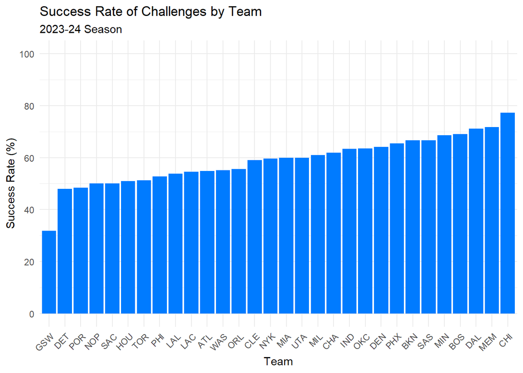

```r
reg_season_teams %>%
  ggplot(mapping = aes(x = reorder(Team.Challenged, success_rate_pct), y = success_rate_pct)) +
  geom_bar(stat = "identity", fill = "#007bff") +
  labs(
    title = "Success Rate of Challenges by Team",
    subtitle = "2023-24 Season",
    x = "Team",
    y = "Success Rate (%)"
  ) +
  theme_minimal() +
  theme(axis.text.x = element_text(angle = 45, hjust = 1)) +
  scale_y_continuous(limits = c(0, 100), breaks = seq(0, 100, by = 20))
```

Yikes. By success rate, the Warriors were abysmal. Let’s explore the relationship between the success rate and the raw number of successes (efficiency and volume) for each team in a plot chart.

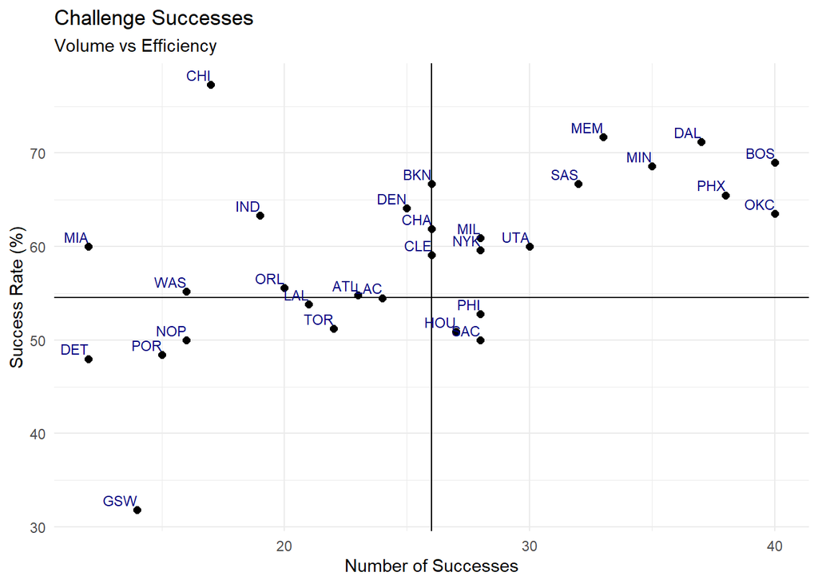

```r
reg_season_teams %>%
  ggplot(mapping = aes(x = no_of_successes, y = success_rate_pct)) +
  geom_point(size = 2) +
  ## Create dividing lines to separate the datapoints into quadrants
  geom_vline(xintercept = (max(reg_season_teams$no_of_successes) + min(reg_season_teams$no_of_successes)) / 2) +
  geom_hline(yintercept = (max(reg_season_teams$success_rate_pct) + min(reg_season_teams$success_rate_pct)) / 2) +
  geom_text(mapping = aes(label = Team.Challenged), vjust = -0.4, hjust = 1, size = 3, color = "navyblue") +
  labs(
    title = "Challenge Successes",
    subtitle = "Volume vs Efficiency",
    x = "Number of Successes",
    y = "Success Rate (%)"
  ) +
  theme_minimal()
```

This chart shows that not only do the Warriors (GSW) have by far the worst success rate in the league (down on y axis), they are in the bottom three in terms of volume as well (left on x axis). No other team came close to matching the Warriors’ struggles in both, leaving them by themselves in the very bottom left corner of the plot. No matter how you slice it, the Warriors were one of if not the very worst team in the league at coach’s challenge usage in 2023-24.

In order to figure out how they can improve, let’s explore the different types of challenges to try to find correlation between challenge types and challenge success. First, let’s look at the success rates for challenges of different calls.

```r
## Create dataframe grouped by call
reg_season_by_call <- reg_season %>%
  group_by(Initial.Call) %>%
  summarize(
    no_of_successes = sum(Challenge.Outcome == "Successful"),
    no_of_attempts = n(),
    no_of_failures = no_of_attempts - no_of_successes,
    success_rate_pct = round((no_of_successes / no_of_attempts) * 100, 1)
  ) %>%
  arrange(desc(success_rate_pct), by_group = TRUE)

## Print dataframe as table
kable(reg_season_by_call %>% select(Initial.Call, no_of_successes, no_of_attempts, success_rate_pct),
      format = "html", table.attr = "class='table table-bordered table-condensed'") %>%
  kable_styling(bootstrap_options = c("striped"), full_width = FALSE)
```

| Initial.Call | no_of_successes | no_of_attempts | success_rate_pct |
| --- | --- | --- | --- |
| Jump Ball | 11 | 12 | 91.7 |
| Away Team Ball | 132 | 164 | 80.5 |
| Home Team Ball | 114 | 149 | 76.5 |
| Goaltending | 21 | 32 | 65.6 |
| Basket Interference | 3 | 5 | 60.0 |
| Defensive Foul | 395 | 727 | 54.3 |
| Double Foul | 1 | 2 | 50.0 |
| Offensive Foul | 74 | 172 | 43.0 |
| Loose Ball Foul | 7 | 19 | 36.8 |

There is an interestingly wide variety in success rates for different calls.

Some of these calls have so few challenges that they aren’t particularly statistically meaningful samples by themselves. Let’s categorize the calls into call types, to simplify things:

- For our purposes, ‘Home Team Ball’ and ‘Away Team Ball’ are functionally the same thing (both are out of bounds calls against the challenging team), so they will both become “Out of Bounds”
- Given the wide variety of forms defensive fouls can take, ‘Double Foul’ and ‘Loose Ball Foul’ are similar enough to defensive fouls to reasonably put all three in their own “Defensive/Misc Foul” category
- “Offensive Foul” will remain its own category
- The remaining three calls (‘Jump Ball’, ‘Goaltending’, ‘Basket Interference’) are miscellaneous and niche enough to warrant their own combined “Other” category

```r
## Create dataframe with calls categorized
reg_season_by_type <- reg_season %>%
  mutate(Initial.Call = case_when(
    Initial.Call == "Away Team Ball" ~ "Out of Bounds",
    Initial.Call == "Home Team Ball" ~ "Out of Bounds",
    Initial.Call == "Defensive Foul" ~ "Defensive/Misc Foul",
    Initial.Call == "Double Foul" ~ "Defensive/Misc Foul",
    Initial.Call == "Loose Ball Foul" ~ "Defensive/Misc Foul",
    Initial.Call == "Jump Ball" ~ "Other",
    Initial.Call == "Goaltending" ~ "Other",
    Initial.Call == "Basket Interference" ~ "Other",
    TRUE ~ Initial.Call
  )) %>%
  group_by(Initial.Call) %>%
  summarize(
    no_of_successes = sum(Challenge.Outcome == "Successful"),
    no_of_attempts = n(),
    no_of_failures = no_of_attempts - no_of_successes,
    success_rate_pct = round((no_of_successes / no_of_attempts) * 100, 1)
  ) %>%
  arrange(desc(success_rate_pct), by_group = TRUE)

## Print dataframe as table
kable(reg_season_by_type %>% select(Initial.Call, no_of_successes, no_of_attempts, success_rate_pct),
      format = "html", table.attr = "class='table table-bordered table-condensed'") %>%
  kable_styling(bootstrap_options = c("striped"), full_width = FALSE)
```

| Initial.Call | no_of_successes | no_of_attempts | success_rate_pct |
| --- | --- | --- | --- |
| Out of Bounds | 246 | 313 | 78.6 |
| Other | 35 | 49 | 71.4 |
| Defensive/Misc Foul | 403 | 748 | 53.9 |
| Offensive Foul | 74 | 172 | 43.0 |

Our newly categorized table makes one thing clear: challenges of non-foul calls are far more likely to be successful than challenges of fouls, especially offensive fouls.

Let’s break down the Warriors’ 2023-24 challenges the same way and visualize it using a stacked bar chart.

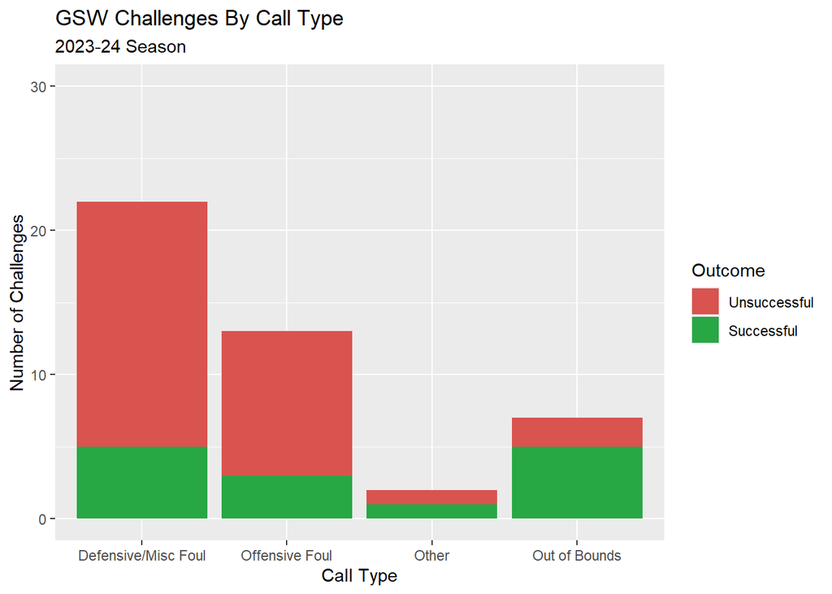

```r
## Create a dataframe with only Warriors challenge data
reg_season_gsw <- reg_season %>%
  filter(Team.Challenged == "GSW") %>%
  select(Date, Initial.Call, Challenge.Outcome, Period, Game.Clock...Review.is.Triggered)

## Create a dataframe with Warriors challenges grouped by call type
gsw_by_type <- reg_season %>%
  mutate(Initial.Call = case_when(
    Initial.Call == "Away Team Ball" ~ "Out of Bounds",
    Initial.Call == "Home Team Ball" ~ "Out of Bounds",
    Initial.Call == "Defensive Foul" ~ "Defensive/Misc Foul",
    Initial.Call == "Double Foul" ~ "Defensive/Misc Foul",
    Initial.Call == "Loose Ball Foul" ~ "Defensive/Misc Foul",
    Initial.Call == "Jump Ball" ~ "Other",
    Initial.Call == "Goaltending" ~ "Other",
    Initial.Call == "Basket Interference" ~ "Other",
    TRUE ~ Initial.Call
  )) %>%
  filter(Team.Challenged == "GSW") %>%
  group_by(Initial.Call) %>%
  summarize(
    no_of_successes = sum(Challenge.Outcome == "Successful"),
    no_of_attempts = n(),
    no_of_failures = no_of_attempts - no_of_successes,
    success_rate_pct = round((no_of_successes / no_of_attempts) * 100, 1)
    )

## Create a long data version of grouped Warriors data
gsw_by_type_long <- gsw_by_type %>%
  pivot_longer(cols = c(no_of_successes, no_of_failures),
               names_to = "Outcome",
               values_to = "Count"
               )

## Plot long data version in a stacked bar chart
  ggplot(gsw_by_type_long, mapping = aes(x = Initial.Call, y = Count, fill = Outcome)) +
    geom_bar(stat = "identity", position = "stack") +
    scale_fill_manual(
    values = c("no_of_successes" = "#28a745", "no_of_failures" = "#d9534f"),
    labels = c("no_of_successes" = "Successful", "no_of_failures" = "Unsuccessful"),
    name = "Outcome"
    ) +
    labs(
    title = "GSW Challenges By Call Type",
    subtitle = "2023-24 Season",
    x = "Call Type",
    y = "Number of Challenges",
    fill = "Outcome"
    ) +
    scale_y_continuous(limits = c(0, 30), breaks = seq(0, 30, by = 10))
```

This chart shows that the Warriors used the vast majority of their challenges on fouls, and that their success rate on these challenges was significantly worse than their success rate on other types of challenges.

For a point of comparison, let’s average out league-wide data and break it down the same way to find the average team’s challenge spread and success rate, once again visualized with a bar chart. We’ll call the Warriors bar chart again immediately afterward to display the two adjacent to each other for convenient visual comparison.

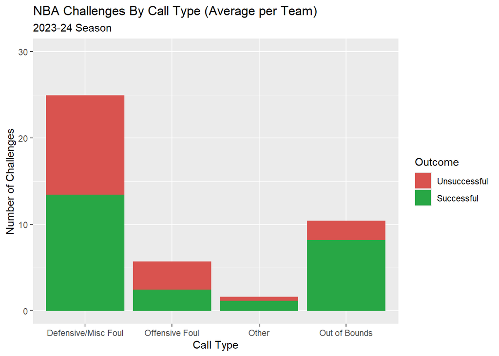

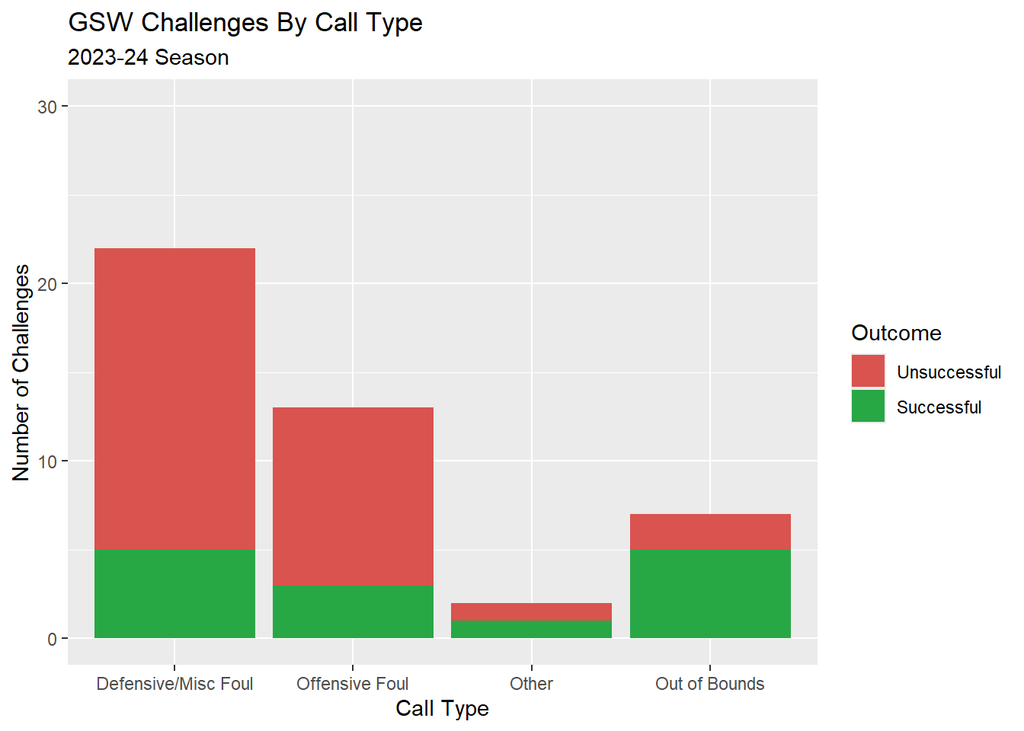

```r
## Divide grouped regular season data by 30 to find average type distribution per team
avg_reg_season_by_type <- reg_season_by_type %>%
  mutate(
    no_of_successes = no_of_successes / 30,
    no_of_failures = no_of_failures / 30,
    no_of_attempts = no_of_attempts / 30
  )

## Create a long data version of the averaged data
avg_reg_season_by_type_long <- avg_reg_season_by_type %>%
  pivot_longer(cols = c(no_of_successes, no_of_failures),
               names_to = "Outcome",
               values_to = "Count"
  )

## Plot long data version in a stacked bar chart
  ggplot(avg_reg_season_by_type_long, mapping = aes(x = Initial.Call, y = Count, fill = Outcome)) +
    geom_bar(stat = "identity", position = "stack") +
    scale_fill_manual(
    values = c("no_of_successes" = "#28a745", "no_of_failures" = "#d9534f"),
    labels = c("no_of_successes" = "Successful", "no_of_failures" = "Unsuccessful"),
    name = "Outcome"
    ) +
    labs(
    title = "NBA Challenges By Call Type (Average per Team)",
    subtitle = "2023-24 Season",
    x = "Call Type",
    y = "Number of Challenges",
    fill = "Outcome"
    ) +
    scale_y_continuous(limits = c(0, 30), breaks = seq(0, 30, by = 10))
```

Looking at the charts, the Warriors have some key differences from the average NBA team in call type distribution and success:

- The Warriors challenged offensive fouls far more often than the average team, while challenging out of bounds calls and non-offensive fouls less often than average.
- The Warriors’ success rate on non-foul calls (Out of Bounds and Other) was reasonably close to league average, while their efficiency on fouls of all types was abysmal. They only won a fraction of their foul challenges, while league average success rate on foul challenges was close to 50%.

## Conclusion

The goal of this analysis was to evaluate the Golden State Warriors’ challenges compared to the rest of the NBA and find ways in which they could improve. In pursuit of this goal, my analysis found the following:

- The Warriors performed extremely poorly in coach’s challenges in 2023-24, grading out as arguably the worst team in the league when looking at volume and efficiency.
- To improve, the Warriors should:
  - Look to challenge more non-foul calls (when appropriate), as they tend to be overturned at higher rates than fouls across the board.
  - Consider challenging fewer offensive fouls, as they are overturned at the lowest rate of all call types (the Warriors challenged twice as many offensive fouls as the average NBA team)
  - Re-evaluate their approach to challenging fouls, as their success rate on foul challenges was astoundingly low.